# Sesión 3. Servicios de acceso remoto y transferencia

Ingeniería de Servicios

2023-2024

# 1 Introducción

En esta sesión se cubren los protocolos para acceso remoto `telnet` y `ssh`, y los de transferencia de archivos `ftp` y `sftp`.

Telnet se verá de forma muy breve, sólo como un método para lanzar comandos remotos en un entorno seguro.

El servicio SSH se muestra inicialmente a nivel de usuario (configuración y uso), con especial hincapié en la autenticación de cliente por el método de clave pública, y posteriormente se presenta el módulo `paramiko` de python que permite escribir programas que puedan crear conexiones ssh, ejecutar comandos remotos, obtener respuestas, etc. lo que tiene utilidad a la hora de automatizar acciones remotas.

FTP relega a un anexo opcional, sólo para el alumno interesado. Se explica tanto a nivel de usuario (instalación de servidor, uso de un cliente de línea de comandos) como de programación mediante el módulo `ftplib` de python, el cual viene “de serie”.

Finalmente se presentan los comandos `scp` y `sftp` a nivel de usuario, y cómo se puede implementar esta misma funcionalidad desde python usando el módulo `paramiko`, ya que este módulo incorpora también el protocolo sftp.

No se usará docker en esta sesión porque estos servicios típicamente estarán instalados en un anfitrión para permitir la conexión y copia de archivos desde otros nodos. No son necesario estos servicios en los contenedores porque ya hemos visto que podemos “conectar” con uno lanzando un proceso `bash` dentro de él, y podemos copiar ficheros con `docker cp`.

# 2 Parte 1: Acceso remoto

## 2.1 Telnet

Este protocolo ha dejado de utilizarse siendo sustituido por `ssh` por su mayor seguridad. Sin embargo, en redes locales seguras o en `localhost` aún puede ser una alternativa válida. También se utiliza a menudo como “cliente genérico” por su capacidad de conectarse a cualquier puerto (y no sólo al estándar del servicio `telnet`), no usando en este caso el protocolo Telnet, sino un protocolo “casi crudo” que sirve para probar otros servidores basados en texto.

### 2.1.1 Instalación del servidor

Ya que Telnet es inseguro, por defecto su servidor viene desactivado en todos los Unix modernos. Para activarlo en Ubuntu Server basta con instalar el correspondiente paquete:

```bash
$ sudo apt-get install telnetd
```

En el caso de Ubuntu esto no sólo instalará el ejecutable del servidor (llamado `telnetd`), sino que además registrará este servicio como uno de los servidos por el servidor de red genérico `inetd`, y reiniciará este servidor para que atienda también al puerto 23 (el estándar de Telnet).

Tras el comando anterior, será posible hacer:

```bash
$ telnet localhost
```

y veremos que nos pide *login* y contraseña para entrar en sesión. También podríamos conectar con la máquina desde Windows usando el cliente `putty`, el cual además de SSH soporta el protocolo Telnet (puerto 23). Haz la prueba.

Recuerda no obstante que Telnet no va cifrado y por tanto cuando introducimos *login* y contraseña estos valores van “en limpio” por la red, por lo que un capturador de tramas como Wireshark instalado en cualquier máquina en el mismo segmento de red permitiría a un atacante descubrir tus credenciales.

Tras la sesión de prácticas será conveniente desactivar de nuevo este servicio, por seguridad. Esto puedes hacerlo editando el archivo `/etc/inetd.conf` (debes hacerlo como administrador), comentando la línea correspondiente al servicio `telnet`, y guardando este fichero al salir, para después ejecutar el siguiente comando:

```bash
$ sudo systemctl restart inetd
```

Tras lo cual, como comprobarás, ya no se puede hacer `telnet` a la máquina. Obviamente para activarlo de nuevo debes editar `/etc/inetd.conf`, descomentar la línea `telnet` y ejecutar de nuevo el comando anterior para reiniciar el servidor `inetd`.

### 2.1.2 El cliente

Desde Linux tienes el comando `telnet` que hemos usado en el apartado anterior para conectar con el servidor. Windows también tiene un comando `telnet` accesible desde la interfaz de comandos, pero a partir de Windows Vista no viene instalado por defecto. No obstante, como hemos visto también antes, el programa `putty` es también un cliente para el protocolo Telnet.

Usando cualquiera de estos clientes es posible conectarse a una máquina para iniciar una sesión interactiva en la que, tras identificarnos con nombre y clave, el servidor telnet remoto arrancará un *shell* que recibirá los comandos que tecleemos en nuestro cliente, y cuya salida recibiremos en nuestro cliente.

Telnet se ocupa de “emular” unas terminales virtuales, (una en el lado del cliente y otra en el lado del servidor) que se ocupan de convertir los comandos y posibilidades de nuestras terminales físicas a un lenguaje común independiente de la terminal física realmente usada. Así, el shell remoto “cree estar” conectado a una terminal real, y el usuario local también interactúa con su terminal como si estuviera directamente conectada al shell remoto.

Como se ha visto en teoría, para poder hacer este trabajo “de emulación”, el protocolo telnet negocia durante la conexión inicial el conjunto de capacidades que tanto cliente como servidor van a soportar para su terminal virtual. Esta negociación no tiene lugar si usamos el cliente telnet para conectar a un puerto diferente del 23.

### 2.1.3 Programación de sesiones no interactivas

Una utilidad que puede tener el conocer someramente el protocolo telnet consiste en escribir un cliente que se conecte con un servidor remoto usando este protocolo para lanzar algún tipo de comando remoto y desconectar después, sin intervención del usuario. Esto puede servir para ejecutar tareas remotas bajo el control del ordenador local. Algunos modems también admiten una conexión vía telnet desde la red local

En este apartado vamos a usar python para conectar a un servidor vía telnet, lanzar un comando remoto y obtener su respuesta.

#### 2.1.3.1 Primera aproximación. Uso de sockets en crudo

Podemos usar la API de sockets para directamente conectar con el puerto 23 del servidor e intentar entrar en él, pero veremos en este caso que la respuesta del servidor contiene un montón de números binarios, que son precisamente los intentos de negociación del servidor de las capacidades de nuestra terminal. Mientras no respondamos al servidor qué características soportamos y cuáles no, la conexión no va a progresar hasta el punto en que nos pida *login* y contraseña, por lo que no podríamos lograr nuestro objetivo de lanzar un comando remoto.

Veámoslo

**Experimento**

Copia el código siguiente en el intérprete python:

```python
import socket

s = socket.socket()
s.connect(("localhost", 23))
respuesta = s.recv(1024)
```

Observa la respuesta que recibes (que es de tipo `bytes`). Python te muestra la representación interna en la que cada byte que no corresponda a un código ASCII se sustituye por una cadena de tipo `\xNN` donde NN es la representación hexadecimal de ese byte. El problema de ésto es que si alguno de los bytes recibidos si que corresponde a un ASCII, se nos mostrará dicho carácter, en lugar de su representación hexadecimal, que en este caso nos interesaría más.

Lo mejor sería tener una función llamada `mostrar_hex()` o similar, que reciba la cadena de bytes `respuesta` y nos muestre cada uno de sus bytes en hexadecimal. No es complicado programarla si tienes en cuenta que puedes recorrer byte a byte dicha cadena mediante `for byte in respuesta:` y puedes usar `hex()` para pasarlo a hexadecimal. Inténtalo.

Verás probablemente que los tres primeros bytes de la respuesta tienen los valores `FF`, `FD` y `18`. Estos constituyen una solicitud por parte del servidor telnet de que activemos una característica extra de nuestra VNT. Debemos responder con otros tres bytes indicando si estamos de acuerdo o no. Qué significan estos bytes está recogido el el estándar (son varios RFCs, pero el principal es el [RFC 854](http://tools.ietf.org/html/rfc854.html)). En particular:

- `FF` (255) es lo que el estándar denomina IAC (*Interpret As Command*), un byte “de escape” que indica que lo que viene detrás no son datos, sino un comando del protocolo telnet. En nuestra respuesta IAC debe ser también el primer byte.
- El siguiente byte, durante la fase de negociación, puede tomar uno de los siguientes cuatro valores:
  - `FB` (251) WILL
  - `FC` (252) WONT
  - `FD` (253) DO
  - `FE` (254) DONT

  En nuestro caso vemos que el servidor ha enviado un `FD` por tanto se trata de una petición “DO”, es decir, nos está pidiendo que activemos cierta característica extra de nuestra terminal.
- El siguiente byte es el código de la característica que nos pide activar. En este caso nos pide la característica 18h, que es la 24 en decimal. Lo que significa cada uno de estos números está recogido en un documento estándar de IANA, llamado [Telnet Options](https://www.iana.org/assignments/telnet-options/telnet-options.xhtml). Consulta ese documento ¿qué capacidad es la número 24? Cada una de estas opciones está descrita con más detalle en otros RFCs. ¿En qué RFC se describe la capacidad que nos solicita el servidor?

El objeto de este experimento es que comprendas que intentar “hablar directamente” con el servidor telnet es muy complejo porque no puedes obviar la fase de negociación, y porque los datos no vienen “limpios”, sino mezclados con bytes que son comandos telnet que habría que filtrar, procesar y responder adecuadamente. Por eso vamos a abandonar esta vía y usar una biblioteca que nos permita subir un nivel.

#### 2.1.3.2 Usando telnetlib

En su biblioteca estándar python viene con `telnetlib`, una biblioteca muy simple que, aunque no es capaz de emular una terminal como puede hacer el cliente `telnet` o `putty`, sí que puede al menos hacer una conexión telnet, ocuparse de la negociación y de filtrar todos los comandos del protocolo, y de hacernos llegar lo que es el texto limpio.

Gracias a esta biblioteca será sencillo efectuar lo que nos proponíamos. Por ejemplo, usaremos python para obtener un listado de la carpeta `/home` del servidor.

**Ejercicio 1**

Consulta la [documentación](http://docs.python.org/3/library/telnetlib.html) del módulo `telnetlib`, y en particular copia el ejemplo que aparece al final, con el nombre `telnet1_ejemplo.py` y prueba a ejecutarlo desde Unix y desde Windows, si tienes python instalado en Windows. Cuando lo ejecutes desde Windows deberás cambiar “localhost” por la IP del servidor Unix.

Modifícalo para que en lugar de la carpeta del usuario muestre el contenido de la carpeta `/home`

La función `read_all()` utilizada al final, llamará repetidamente a `recv()` sobre el socket de conexión, hasta que detecte el cierre de dicho socket (fin de transmisión). Nos devolverá todo el texto recibido (eliminando los comandos binarios del protocolo), en forma de cadena de bytes. Verás que recibimos el mensaje de bienvenida del sistema, el eco del comando que enviamos (`ls`) y la respuesta de ese comando, así como el eco del `exit` final.

Aunque el ejemplo tomado de la documentación de Python decodifica lo recibido con el encoding `"ascii"`, esto podría fallar si en la respuesta viniera algún carácter no ascii (por ejemplo, si algún fichero de los listados en la carpeta tiene acentos o eñes en su nombre). Necesitamos saber qué codificación usa el shell remoto para este caso, y así poder decodificarlo apropiadamente. En nuestro caso el encoding sería UTF-8, que es el usado por defecto por Ubuntu Server 18.04. Por desgracia el protocolo telnet no puede informarnos de tal cosa ya que para él esto es transparente y asume que el shell remoto y la terminal local usan ambos la misma codificación.

En lugar de `read_all()` podemos usar también `read_until()`, la cual también recibe bytes del socket y los va procesando dejando el texto limpio, pero se detiene cuando recibe cierta secuencia de bytes que le pasamos como parámetro. Este es el truco usado para detenerse cuando el sistema remoto está pidiendo el `login:` y la `Password:` y así poder enviarle estos datos en el momento oportuno.

Piensa cómo usarías `read_until()` para leer (y descartar) el mensaje de bienvenida del sistema, y así quedarse sólo con el comando `ls` y su salida. Pista: el *prompt* del *shell* remoto termina siempre en dolar (`$`). Impleméntalo en el fichero `telnet1_ejemplo_mejorado.py`.

**Ejercicio 2**

Copia en la máquina Linux, a tu carpeta *home*, el programa servidor que escribiste en la sesión sobre protocolos UDP, llamado `udp_servidor3_con_ok.py`. Este era un servidor que esperaba por datagramas en el puerto `9999` y devolvía otros datagramas de confirmación conteniendo un “OK”.

En este ejercicio vamos a usar telnet para arrancar remotamente ese servidor, en el caso de que no estuviera ya en ejecución. Para ello debes escribir un programa llamado `telnet2_lanza_servidor.py` que:

1. Se conecte usando `telnetlib` con el servidor Linux, usando la misma técnica que en el ejercicio anterior, pero en esta ocasión sin preguntar al usuario nombre y clave, sino incrustando éstas directamente en el código fuente (es una mala práctica de cara a la seguridad, pero lo haremos así en igualmente para este ejercicio)
2. Una vez conectado, lee la respuesta del telnet usando `read_until(b"$")` esto leerá lo que el shell remoto nos envía, hasta que se reciba un signo dólar. Ya que el signo dólar es parte del *prompt*, al recibirlo sabremos que el *shell* remoto está listo para recibir comandos.
3. Envía el comando `ps -ef\n` que lista todos los procesos del usuario (¡no olvides enviar el `\n` al final!)
4. Usa de nuevo `recv_until()` para esperar al próximo *prompt* y captura la respuesta en una variable. Esa respuesta contendrá la salida del comando `ps -ef` que le habíamos pedido.
5. Comprueba si la respuesta recibida contiene la cadena `udp_servidor3_con_ok.py`, lo que denotaría que el servicio está en ejecución. En ese caso imprime “El servidor ya está en ejecución” y terminará.
6. Si esa cadena no está presente (el servidor no está en ejecución), lo lanzaremos, enviando por telnet la orden `nohup python3 udp_servidor3_con_ok.py &\n` (¡no olvides el retorno de carro!).
   - El `&` final es para que el shell devuelva el *prompt* y así poder lanzarle un `exit` después.
   - El `nohup` inicial es para que el servidor siga corriendo cuando cerremos la conexión telnet (de lo contrario, al estar lanzado desde esta “terminal”, moriría al cerrar telnet). Se creará un fichero llamado `nohup.out` que contendrá la salida del comando, en lugar de ir a la terminal.
7. Espera un segundo para dar tiempo a que el servidor arranque (`time.sleep(1)`)
8. Envía el comando `exit\n` para terminar el shell remoto y por tanto la sesión telnet.
9. Recoge la respuesta del servidor con `read_all()` y muéstrala en pantalla para depuración.

Prueba a lanzar este programa, si es posible desde otra máquina. Entra después en la máquina Ubuntu y verifica que el servidor ha sido arrancado y está en ejecución. Si algo ha ido mal, puedes mirar el contenido del fichero `~/nohup.out`, que contiene la salida del comando que has lanzado con `nohup` y puede darte pistas sobre el problema.

Lanza de nuevo el programa que has escrito y comprueba si esta vez te dice que el servidor ya estaba en ejecución. Desde una terminal en Ubuntu, mata al servidor (`kill` del proceso cuyo PID averiguarás con `ps -ef`), y lanza de nuevo el script desde otra máquina para ver que arranca de nuevo el servidor.

## 2.2 SSH

SSH puede proporcionar diferentes servicios a través de diferentes canales. Nos centraremos inicialmente en el servicio de terminal remota (o *shell* remoto), que nos ofrece la misma funcionalidad que Telnet pero sobre un canal cifrado y con garantías de autenticación de los extremos.

### 2.2.1 Servidor

En la máquina a la que nos queremos conectar y en la que ejecutaremos los comandos remotos necesitamos tener:

- Un servidor del protocolo SSH (habitualmente el proceso se llama `sshd`)
- Una cuenta de usuario (la cuenta `alumno` nos serviría para esta práctica).

En esta sesión usaremos como servidor la máquina virtual Ubuntu, en la que ya tienes `sshd` instalado y funcionando. Si no fuera así, debes instalar el siguiente paquete:

```bash
$ sudo apt-get install openssh-server
```

Esto instalará la parte servidor de una implementación de ssh de código abierto llamada “OpenSSH”. La parte cliente viene preinstalada por defecto en Linux y en OSX y se llama `ssh`, si bien en esta práctica apenas la usaremos porque nos conectaremos desde Windows usando el cliente `putty` y VisualStudio Code.

Como parte del proceso de instalación del servidor OpenSSH, se llegará a un punto en que los *scripts* de instalación lanzarán el comando `ssh-keygen`, el cual generará una pareja de claves privada/pública para diferentes algoritmos de firma digital (los más comunes son RSA1, usado por SSH1, y RSA o DSA usados por SSH2). Esto suele ser transparente al usuario, pero es un paso crucial ya que lo que se genera en ese momento es la *host key* que el servidor usará para autenticarse ante el cliente y para firmar digitalmente la clave de sesión negociada.

Puedes comprobar que tienes estas parejas de claves privada/pública correctamente generadas echando un vistazo a la carpeta donde están guardadas:

```bash
$ ls /etc/ssh
moduli                ssh_host_ecdsa_key        ssh_host_rsa_key
ssh_config            ssh_host_ecdsa_key.pub    ssh_host_rsa_key.pub
ssh_host_dsa_key      ssh_host_ed25519_key      ssh_import_id
ssh_host_dsa_key.pub  ssh_host_ed25519_key.pub  sshd_config
```

Puedes ver aquí, además de los ficheros de configuración `ssh_config` y `sshd_config`, una serie de ficheros con la palabra `host` como parte del nombre. Algunos de estos ficheros llevan la extensión `.pub` y otros no. Los que llevan la parte `.pub` son la clave pública y los que no, son la parte privada. Estos ficheros (especialmente los que guardan la clave privada) deben tener permiso de lectura sólo para el usuario `root` ya que si otro usuario del sistema pudiera acceder a ellos, podría “robarlos” para instalarlos en otro servidor y hacerse pasar por el nuestro.

**Experimento**

Comprueba que sólo el usuario `root` puede acceder a las claves privadas, mientras que cualquiera puede leer (pero no escribir) los ficheros de claves públicas. Para ello haz un `ls -l /etc/ssh` y observa los permisos UNIX.

Comprueba que el servidor `sshd` está en ejecución con el comando `ps aux|grep sshd`. Verás que hay un proceso “principal” llamado `/usr/sbin/sshd` cuyo propietario es `root`. Éste proceso se ocupa de esperar clientes en el puerto 22 y para cada uno que llega lanza otro `sshd` “hijo” que lo atenderá. Este hijo a su vez lanzará otro más para conectarlo a una terminal virtual. Por tanto verás varias instancias de `sshd` en ejecución: la principal y dos más para cada cliente conectado al servidor.

### 2.2.2 Clientes

Para las máquinas Unix y para OSX, el cliente es el comando `ssh`. Este comando también está disponible en Windows si se ha instalado OpenSSH (puedes comprobar si es tu caso abriendo una terminal y ejecutando en ella el comando `ssh`). El comando que soporta múltiples opciones pero en su forma más simple sería:

```bash
$ ssh usuario@maquina
```

para conectarse a la máquina especificada usando el usuario especificado (si no especificamos usuario, automáticamente asumirá que el nombre del usuario remoto es el mismo que el del usuario local que está ejecutando el comando `ssh`).

En máquinas Windows, en las que no esté instalado OpenSSH la solución más popular es el programa llamado `putty`, el cual es muy fácil de instalar porque consiste simplemente en el ejecutable `putty.exe` que no requiere instalación. La versión más reciente de PuTTY, a fecha de octubre de 2023, es la 0.79. Puedes comprobar si tienes la última versión pulsando el botón “About” de la ventana que aparece al lanzar el programa.

Cuando el cliente ssh se conecta al servidor ssh, tras la fase de negociación en la que se ponen de acuerdo con respecto a qué algoritmos utilizar (por ejemplo, si la firma digital va a usar RSA1, RSA2 o DSA), el servidor envía la clave pública apropiada al cliente (es decir, el contenido del archivo `/etc/ssh/ssh_host_rsa_key.pub`, por ejemplo).

Si es la primera vez que el cliente se conectaba a ese servidor, éste no tendrá forma de saber si la clave que está recibiendo es realmente la del servidor o la de un impostor que intenta hacerse pasar por él (usando su mismo nombre, mediante ataques al DNS, o su misma IP, mediante ataques de *IP Spoofing*, por ejemplo). Como no tiene forma de saberlo, le pregunta al usuario, y veremos una pantalla como esta:

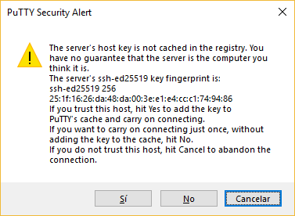

Si en vez de PuTTY usáramos un cliente de línea de comandos, veríamos lo siguiente:

```bash
$ ssh alumno@192.168.2.32
The authenticity of host '192.168.2.32 (192.168.2.32)' can't be established.
ECDSA key fingerprint is SHA256:7AMMrgzhQ8eblDSfTRE+Xw2DaP+C2EZXTNJYGNdl6e0.
Are you sure you want to continue connecting (yes/no)?
```

En ambos casos nos está preguntando si estamos seguros de que el servidor al que intentamos conectar no es un impostor. Como pista, nos muestra el *fingerprint* de la clave pública que acaba de recibir de ese servidor. En particular podemos ver que cuando conectamos desde PuTTY nos ha ofrecido la clave del algoritmo `ed25519`, mientras que desde otra terminal nos ha ofrecido la clave del algoritmo `ECDSA`, de las diferentes claves que tiene. El *fingerprint* no es más que un *hash* de la clave pública recibida.

¿Qué debería hacer el usuario con ese *hash*? Si el usuario está en un entorno seguro en el que no cabe sospechar ataques al DNS ni *IP spoofing*, el usuario podría confiar directamente en la IP que le está mostrando el mensaje (entre paréntesis) y compararla con la que tiene el servidor al que intenta conectar. En ese caso podría ignorar el *fingerprint* y aceptar la clave pública que ha recibido como buena. En ese caso `putty` o `ssh` almacenará una copia de esa clave y cuando en el futuro se conecte de nuevo a ese servidor y reciba la misma clave ya sabrá que es buena y no preguntará más.

Si el usuario en cambio está conectándose desde un entorno inseguro (por ejemplo un cibercafé, o una red wifi pública), debería conocer de antemano el *fingerprint* del servidor. Podría llevarlo apuntado en un papel o en el teléfono y compararlo con el que `putty` le está mostrando. Para obtener ese *fingerprint* deberá haber entrado al menos una vez desde un entorno seguro, y haber ejecutado el siguiente comando en el servidor:

```bash
# Obtener fingerprint de la clave ECDSA, usada por cliente ssh
$ ssh-keygen -l -f /etc/ssh/ssh_host_ecdsa_key.pub
256 SHA256:7AMMrgzhQ8eblDSfTRE+Xw2DaP+C2EZXTNJYGNdl6e0 root@is-02 (ECDSA)

# Obtener fingerprint de la clave ed25519, usada por PuTTY
$ ssh-keygen -l -f /etc/ssh/ssh_host_ed25519_key.pub
256 SHA256:n1DxDv/jvuG8p+v1TB7L7CoqjDm+hPMufQDxCglFVyE root@is00 (ED25519)
```

El comando `ssh-keygen -l` calcula el *fingerprint* de la clave almacenada en el fichero que se le pasa con la opción `-f`. Con la opción `-E` se puede especificar qué hash aplicará a la clave para sacar el fingerprint. Si no se especifica se usará SHA256, que es el que queremos en este caso. El usuario precavido debería llevarse una copia de los *fingerprint* para cada algoritmo (DSA, RSA, etc.), bajo diferentes hashes, por si su cliente le muestra otro.

**Ejercicio 3**

Usando la consola de la máquina virtual Ubuntu, entra en sesión. Esta es la forma más segura posible de entrar en el sistema, ya que lo estaremos haciendo directamente en su consola, sin conexiones de red.

Dentro de ella, averigua el *fingerprint* `sha256` de la clave pública para el algoritmo `ed25519`. Anota (al menos sus primeras cifras) en un papel.

Usando `putty`, conecta a la máquina. Si no es la primera vez que lo haces no te preguntará nada y no veremos la pantalla de advertencia con el *fingerprint*.

Si borramos el almacén donde `putty` guarda las claves por él conocidas (lo que sería el archivo `known_hosts` de unix), e intentamos reconectar, entonces nos aparecerá de nuevo esa pantalla como la primera vez. Por desgracia `putty` no guarda esta información en un archivo, sino en claves de registro de Windows, que son algo más difíciles de borrar:

- Desde el menú *Inicio* lanza el comando `regedit` (puedes hacerlo por su nombre)
- Dentro de regedit, busca la clave `HKEY_CURRENT_USER` → `Software` → `SimonTatham` → `PuTTY` → `SshHostKeys`
- Verás todas las claves públicas que tiene almacenadas de todos los sitios a los que te hayas conectado usando PuTTY. Busca la que corresponde a tu servidor Ubuntu (en la columna “nombre” podrás encontrarlo por la IP o nombre de dominio de la máquina).
- Borra esa entrada usando la tecla *Supr*.

Conecta de nuevo al servidor y observa cómo ahora te sale de nuevo la advertencia y el *fingerprint*. Comprueba que coincide con el que obtuviste en la consola. Si no concordaran, comprueba que realmente `putty` y el servidor están intentando usar ED25519 (el mensaje antes del *fingerprint* te indica qué algoritmo usan). Deberían ser iguales, de lo contrario ¡la universidad no es un lugar seguro!

::: **Ejercicio 3bis (opcional)**

Repite el ejercicio 3 pero usando VSCode como cliente, en lugar de Putty. En realidad llevas usando VSCode como cliente desde el inicio de las prácticas, por lo que mientras la máquina virtual Ubuntu no cambie de IP ya tendrás su clave pública guardada en `~/.ssh/known_hosts`.

Edita ese fichero y borra la línea correspondiente a la IP que tiene hoy tu máquina virtual Ubuntu.

Inicia una nueva sesión de VSCode remoto y verás cómo te muestra el fingerprint para que lo verifiques. Compáralo con el averiguado en la consola (verifica que VSCode te esté mostrando el mismo algoritmo de hash y para la misma clave pública). :::

El resto ya lo conoces, el servidor te pide usuario y contraseña tras lo cual te permite acceder y ejecutar comandos como si estuvieras en su consola.

Pero el nombre de usuario y contraseña es solo uno de los métodos de autenticación del cliente que SSH soporta. Otro que puedes usar es el basado en claves públicas/privadas, pero esta vez generadas en el cliente, lo cual es el tema del siguiente apartado.

### 2.2.3 Claves públicas, agentes

El tener que teclear una contraseña puede ser un problema de seguridad. No por el transporte de la contraseña hacia el servidor, ya que ese va cifrado por la capa SSH-TRANS de forma altamente segura, sino por otras razones, como:

- Alguien podría adivinar tu contraseña (por ejemplo atacando al servidor, robando el archivo `/etc/shadow` y usando fuerza bruta. Si la clave es sencilla, un ataque de diccionario podría dar resultado).
- Alguien podría estar observando mientras tecleas la contraseña, y tomar nota de ella.
- El ordenador en que tecleas la contraseña podría estar infectado con un *keylogger* que registra las pulsaciones de teclado y las almacena o envía por Internet.

El método de autenticación mediante claves públicas evita el tener que teclear una contraseña que deba ser transmitida al servidor o almacenada en el mismo.

En este método el cliente genera una pareja de claves privada/pública, y el usuario mantiene una copia de ambas en un lugar razonablemente seguro (su carpeta de usuario, o un lápiz USB). Para mayor seguridad, la parte privada de la clave se cifrará con un algoritmo simétrico y con una contraseña robusta. De este modo, si alguien accediera al archivo que contiene la clave privada, aún así no le sería de utilidad sin conocer la contraseña que lo desbloquea.

Por tanto se tiene una seguridad de *doble vía*, ya que para autenticarse por este método se requieren dos ítems:

- Los ficheros de claves privada/pública
- La contraseña que descifra el fichero con la clave privada

Si un atacante consigue sólo uno de los dos ítems, no podrá autenticase correctamente haciéndose pasar por ti.

Veamos cómo configurar PuTTY para que use este tipo de autenticación.

Conéctate a la [página de descarga de PuTTY](http://www.chiark.greenend.org.uk/~sgtatham/putty/download.html) y descarga el programa llamado `puttygen.exe`.

Este programa es el encargado de generar la pareja de claves. Su equivalente de línea de comandos para Unix, MacOS, o Windows con OpenSSH instalado se llama `ssh-keygen`.

**Ejercicio 4**

Ejecuta el PuTTYgen y verás una ventana como la siguiente:

[figure not shown]

Selecciona el tipo de clave `RSA` (seleccionado por defecto), y pulsa el botón *Generate*. Mueve el ratón aleatoriamente para generar aleatoriedad, hasta que la barra verde se complete. Al cabo de un rato obtendrás una pantalla como la siguiente:

[figure not shown]

Introduce una frase de paso (y repítela debajo). Es la contraseña que servirá para cifrar la parte privada de la clave. Asegúrate de que la contraseña sea suficientemente larga y de que no se te olvide. No uses la misma contraseña que hayas puesto al usuario `alumno` dentro de la máquina Ubuntu, para diferenciar mejor cuándo se usa una u otra.

Finalizada la creación de la pareja de claves, éstas se encuentran todavía en RAM. Es necesario guardarlas en disco para poder usarlas en la conexión SSH.

Pulsa el botón *Save private key* y elige un lugar donde guardar el archivo, al que puedes darle cualquier nombre. El almacén puede ser un lápiz USB. Recuerda que si pierdes el lápiz y alguien se hace con ese archivo, aún no podrá hacer uso de él mientras no conozca la frase de paso que has puesto en el punto anterior.

Pulsa el botón *Save public key* y guarda la parte pública en la misma carpeta en que guardaste la parte privada.

El paso siguiente es configurar PuTTY para que use esta pareja de claves como mecanismo de autenticación ante el servidor.

**Ejercicio 5**

Ejecuta el programa PuTTY. Si tenías una sesión guardada (*Saved Sessions*) para acceder al servidor Ubuntu, carga esa sesión, para modificarla. Si no la tenías, introduce la IP del servidor , asegúrate de que esté elegido el protocolo SSH (puerto 22), e introduce un nombre para la sesión (por ejemplo IngServ) y pulsa el botón *Save*.

En la lista de opciones del panel izquierdo, elige *Connection* → *SSH* → *Auth* → *Credentials*. Verás un panel como el siguiente:

[figure not shown]

Pulsa el botón *Browse…* y elige el archivo con la clave privada que guardaste antes, al ejecutar PuTTYgen.

Vuelve a la opción primera, *Session* y pulsa de nuevo *Save* para guardar el cambio que acabas de hacer en esta sesión (esto es, añadirle un mecanismo de autenticación por clave pública).

Lo anterior le dice a PuTTY que cuando se conecte al servidor indicado en esa sesión, intente en primer lugar una autenticación mediante clave pública. Lo que hará PuTTY es enviar tu clave pública al servidor, el cual cifrará con ella un “reto” que enviará a PuTTY para que éste trate de descifrarlo con tu clave privada. Si lo logra, entonces habrá demostrado su identidad y el servidor ssh te dejará entrar sin pedirte la clave Unix de tu usuario en esa máquina.

Si el método de autenticación basado en claves públicas falla, el servidor y PuTTY pasarán al siguiente método de autenticación que hubieran acordado, que será probablemente el de pedirte el usuario y contraseña de la máquina Unix.

Probemos si funciona.

Pulsa el botón *Open* en la ventana de PuTTY.

Se inicia una conexión con el servidor, el cual te pide el nombre de usuario en la máquina remota, el cual es `alumno`.

Si quieres evitar que te pregunte este nombre, puedes introducirlo en la configuración de la sesión de PuTTY, en el apartado *Connection* → *Data* (recuerda guardar de nuevo la sesión para que el cambio se aplique en el futuro)

Una vez proporcionado el nombre de usuario, comenzará el intento de autenticación por clave pública. ¿Ha funcionado? Si te está pidiendo la clave del usuario `alumno` es que no ha funcionado y ha pasado al siguiente método de autenticación (el llamado *keyboard interactive*).

Verás que no ha funcionado. Y es que no hemos terminado de configurar todo. Tal como están las cosas, cuando PuTTY resuelve el reto, sólo ha demostrado que posee la clave privada que es pareja de la que le ha enviado al servidor. Pero nada prueba que esa clave privada pertenezca realmente al usuario `alumno`. Cualquiera puede genera un par de claves privada/pública, y por tanto cualquiera puede resolver correctamente el reto sin necesidad de ser el usuario `alumno`, usando sus propias claves en lugar de las del usuario `alumno`.

Para que el servidor tenga garantías de que quien está al otro lado, usando PuTTY es realmente el usuario `alumno`, necesita tener previamente una copia de la clave pública que ese usuario acaba de generar. Con ella, si el cliente resuelve correctamente el reto, tendría la garantía de que ese cliente posee la clave privada pareja, y que por tanto efectivamente es el usuario `alumno`.

Así pues, es necesario “subir” al servidor ssh una copia de la clave pública.

**Ejercicio 6**

Entra en sesión en el servidor SSH. Esta vez todavía tendrás que autenticarte por el método clásico de usuario y contraseña Unix.

- Una vez dentro, ve a la carpeta `~/.ssh`
- Edita el fichero llamado `authorized_keys`. Este fichero contiene copias de todas las claves públicas que el usuario quiera usar para autenticarse ante este servidor. Si no existía el fichero, créalo.
- Ve de nuevo a la ventana en que estaba ejecutándose PuTTYgen. ¿La has cerrado? No importa, ejecútalo de nuevo y pulsa el botón *Load* para cargar el fichero con la clave privada que guardaste en su momento al generarlas. En el momento de cargar ese fichero te pedirá tu frase de paso.
- Verás que en la parte superior de la ventana, debajo del rótulo que dice "_Public key for pasting into OpenSSH authorized_keys file" hay una larga secuencia de letras y números. Selecciona todo ello con el ratón (o más rápido, pulsando `Alt-P`).
- En la terminal en que estabas editando `authorized_keys`, pega la secuencia de letras y números que acabas de copiar de PuTTYGen.
- Guarda el archivo y sal del servidor.

La próxima vez que entres en el servidor algo habrá cambiado.

Usando de nuevo PuTTY, entra en la sesión que tenías guardada.

Si lo has hecho todo bien, tras pedirte el usuario (`alumno`) te pedirá la *passphrase* de tu clave privada. No te está preguntando ahora por la contraseña del usuario `alumno`, sino por la contraseña con que cifraste tu clave privada. PuTTY la necesita para acceder a tu clave privada y resolver el reto del servidor.

Observa que una vez que has creado esta pareja de claves pública/privada, puedes usar el método anterior para pegar la parte pública en todos los servidores Unix que quieras. En cada uno de ellos lo añadirás al final del correspondiente fichero `~/.ssh/authorized_keys`. De este modo sólo tendrás que recordar una contraseña: la frase de paso para tu clave privada, en lugar de tener que recordar una contraseña diferente para cada servidor (o peor, usar la misma en todos, lo que es inseguro pues si uno de ellos es atacado y la clave capturada, el atacante podría entrar en tu nombre en cualquier otro que use la misma clave).

A pesar de lo farragosa que resulta la configuración anterior, una vez está hecha para el usuario entrar en sesión es tan sencillo como lo era antes. Sólo que en lugar de proporcionar la clave Unix del usuario, ha de proporcionar la contraseña (frase de paso) de su clave privada.

Aunque desde el punto de vista del usuario puede no haber diferencia, lo cierto es que el mecanismo basado en claves públicas es mucho más seguro ya que, incluso si alguien te observa mientras tecleas la contraseña, esa información no le será útil a menos que te robe también el archivo donde guardas la clave privada. Y si esto ocurriera bastaría entrar en el servidor ssh para borrar la línea apropiada del fichero `authorized_keys`, con lo que el ladrón ya no podría usar esa clave para autenticarse ante este servidor.

**Ejercicio opcional**

Configura VSCode para que también use autenticación de clave pública a la hora de entrar en la máquina Ubuntu. Para ello necesitas:

- Generar una pareja de claves privada/pública. Podría usarse la misma pareja que ya se generó con `puttygen`, pero no están en el formato adecuado para OpenSSH, que es la implementación que usa VSCode. Aunque `puttygen` permite guardarlo en otros formatos, puede resultar más sencillo simplemente ejecutar el comando `ssh-keygen` desde una consola de Windows.
- Decirle a VSCode que utilice autenticación por clave pública para la sesión “IngenieriaServicios” (o como quiera que la hayas llamado tú en el archivo `~/.ssh/config` usado por VSCode, es justo la cadena que aparece tras la palabra `Host`). Para ello añade a la configuración de ese `Host` una línea que diga:

  ```
  IdentityFile C:\Users\jldiaz\.ssh\id_rsa
  ```

  Cambiando apropiadamente el nombre de la ruta y el del fichero de clave privada para que sea el generado en el paso anterior.
- Añadir la parte pública de esta clave al fichero `~/.ssh/authorized_keys` que hay en tu servidor Ubuntu (allí estará ya la que antes añadiste para PuTTy).

Para probar si funciona intenta abrir una nueva sesión remota con VSCode y comprueba que te pide la frase de paso de la clave privada.

### 2.2.4 Agentes

Aún así, el usuario tiene que seguir introduciendo una contraseña cada vez que se conecta a un servidor. Si trabajas a menudo en un entorno en el que tienes que abrir y cerrar muchas conexiones SSH, tener que teclear la frase de paso cada vez puede ser un engorro. ¿Puede evitarse?

La respuesta son los *agentes*.

Un agente es un proceso que está cargado en memoria y que tiene una copia *desencriptada* de tu clave privada, almacenada en RAM. Los clientes SSH (y PuTTY entre ellos), pueden detectar si hay un agente en ejecución, y en ese caso le piden a él la clave privada apropiada para resolver el reto del servidor. El agente le suministrará esa clave y no se pedirá al usuario la correspondiente frase de paso, ya que ésta no es necesaria porque el agente tiene la clave privada ya desencriptada.

¿Cómo llega tu clave privada al agente? ¿Cómo es que la tiene desencriptada si nadie puede acceder a ella sin conocer la frase de paso? Obviamente lo que ocurre es que tú tienes que cargar previamente esa clave en el agente, y en el momento de la carga se pedirá tu frase de paso. Pero ésto sólo ocurrirá una vez, al cargar la clave en el agente, y no *cada vez* que te conectes a un servidor ssh que requiera esa clave.

Vamos a probarlo.

**Ejercicio 7**

- Ve a la [página de descarga de PuTTY](http://www.chiark.greenend.org.uk/~sgtatham/putty/download.html) y bájate el fichero llamado `pageant.exe`. No requiere instalación, puedes dejarlo en cualquier carpeta.
- Ejecuta el programa. Aparentemente no ocurre nada, pero en la zona de notificación habrá aparecido un pequeño icono, con forma de terminal con sombrero.

[figure not shown]

- Pulsa con el botón derecho sobre ese icono y elige la primera opción *View Keys*. Saldrá una ventana con todas las claves privadas que el agente tiene en memoria. Inicialmente no tiene ninguna.
- Pulsa el botón *Add Key*, y en el selector de archivos ve a la carpeta donde tienes la clave privada que generaste con PuTTYgen.
- Al cargar esa clave, te pedirá su frase de paso. Será la única vez que tengas que introducirla (mientras PageAnt esté en ejecución, claro está).
- Verás ahora una línea con el *fingerprint* de esa clave.

Ya no tienes que hacer nada más. El resto es automático. Cuando uses PuTTY para conectarte a un servidor en el que hayas configurado la autenticación por clave privada/pública, ocurrirá lo siguiente:

1. PuTTY le enviará al servidor ssh la clave pública que hayas especificado en la configuración de esa sesión (recuerda, en las opciones de *SSH* → *Auth* → *Credentials* )
2. El servidor, tras comprobar que la clave pública está en el archivo `authorized_keys` de ese usuario, cifrará un reto con esa clave pública y se la enviará a PuTTY.
3. PuTTY, para descifrar el reto, necesita la correspondiente clave privada. Pero detecta que PageAnt está en ejecución, por lo que le pregunta primero a él si tiene esa clave privada.
4. PageAnt la tiene, y se la da a PuTTY. Éste completa el reto criptográfico y así se autentica ante el servidor.
5. El servidor da acceso al cliente. El usuario ha entrado en sesión sin tener que teclear ninguna contraseña.

Comprueba que funciona. Basta que inicies de nuevo sesión en el servidor desde PuTTY y veas que no te pide contraseña. Puedes repetir esto cuantas veces quieras.

Termina el proceso PageAnt (pulsa con el botón derecho del ratón sobre su icono en la zona de notificaciones y elige *Exit*).

Si intentas entrar de nuevo, esta vez te pedirá la frase de paso de tu clave privada. Si no se la das, irá al siguiente método de autenticación que es la contraseña Unix.

**(Opcional)**

Por desgracia `pageant` es un agente compatible sólo con PuTTy y no con VSCode (OpenSSH), por lo que al usar conexiones remotas vía ssh desde VSCode te seguirá pidiendo la contraseña de la correspondiente clave privada (o la del usuario Unix si no configuraste VSCode para usar claves públicas en esa conexión).

El equivalente a `pageant` compatible con OpenSSH es `ssh-agent`. Debes ejecutar éste en una consola Windows. Una vez ejecutado podrás usar `ssh-add` para añadirle ficheros de claves privadas (el creado en el anterior ejercicio opcional).

Ya que VSCode usa el `ssh` de OpenSSH, que está preparado para detectar un `ssh-agent` en ejecución, la próxima sesión remota que abras desde VSCode te permitirá entrar en la máquina Ubuntu sin solicitarte contraseña (si todo ha sido correctamente configurado). Esto durará mientras `ssh-agent` esté en ejecución, es decir, hasta que cierres tu sesión de usuario en Windows.

En algunos sistemas, para mayor seguridad, las cuentas de usuario no tienen contraseña Unix, por lo que el único método para entrar en sesión es configurar correctamente la autenticación mediante clave privada/pública. Esto es típico en los servidores alojados en la nube.

### 2.2.5 Desde python

Entre las bibliotecas estándar de Python no hay ninguna que implemente el protocolo SSH. Sin embargo es posible instalarle un módulo extra, llamado `paramiko`, desarrollado por un grupo de programadores coordinados actualmente por Jeff Forcier.

Esta implementación está hecha en python puro, pero utiliza llamadas al módulo `pycripto` para todo lo que se refiere a los algoritmos criptográficos. El módulo `pycripto` por tanto debe estar también instalado, pero éste por desgracia no está escrito en python puro (tiene partes escritas en C, para mejorar la eficiencia). Con `pip install` (preferiblemente en un entorno virtual) se puede instalar de forma sencilla porque existen versiones binarias (con las partes en C ya compiladas) para la mayoría de las plataformas.

Instalémoslo así:

1. Crea un entorno virtual con:

   ```bash
   $ python3 -m venv ~/paramikoenv
   ```

2. Actívalo con:

   ```bash
   $ source ~/paramikoenv/bin/activate
   (paramikoenv) $
   ```

3. Instala en él paramiko:

   ```bash
   (paramikoenv) $ pip install --upgrade pip  # Hay que tener la última versión de pip
   (paramikoenv) $ pip install paramiko
   ```

Paramiko es una biblioteca muy compleja (un vistazo a [su documentación](http://docs.paramiko.org) ya da una idea), por lo que no se verá en profundidad en esta asignatura, pero se menciona su existencia para el alumno interesado.

En esta práctica nos limitaremos a adaptar el mínimo ejemplo que figura en el `README` para que funcione en nuestro entorno de desarrollo y para ilustrar conceptos que ya han aparecido en apartados anteriores al trabajar con PuTTY.

#### 2.2.5.1 Ejemplo mínimo

El siguiente ejemplo está basado en el que viene en el `README` de paramiko. Se trata de conectar a un servidor remoto, ejecutar allí el comando `ls` y obtener el resultado de ese comando para mostrarlo localmente. La conexión se hará por SSH de forma segura, autenticando correctamente al servidor y al cliente.

Recuerda que para ejecutar cualquiera de los ejemplos que siguen necesitas tener activado el entorno `paramikoenv` que acabamos de crear.

Comencemos por una versión extremadamente simple, que no va a funcionar. Copia el siguiente código a un fichero llamado `ssh_ejemplo_mal.py`

```python
import paramiko
import time
client = paramiko.SSHClient()
client.connect('localhost', username='alumno', password='clave-mal')
print("Conectado!!")

# Ejecutar comando remoto, redireccionando sus salidas
stdin, stdout, stderr = client.exec_command('ls')

# Mostrar resultado de la ejecución (rstrip quita los retornos de carro)
for line in stdout:
    print(line.rstrip())
time.sleep(1)  # Dar tiempo a que se vacie el buffer
client.close()
```

Quizás creas que no funcionará correctamente porque hemos puesto `'clave-mal'` en lugar de la verdadera clave, pero lo cierto es que la conexión ni siquiera progresa lo suficiente como para llegar a la autenticación del usuario.

**Experimento**

Ejecuta el ejemplo anterior. ¿Qué mensaje de excepción obtienes? ¿Qué crees que puede significar?

Lo que ha ocurrido es que la clave pública que el servidor nos ha enviado como parte del protocolo de autenticación, es desconocida para paramiko, y éste por defecto genera una excepción para este caso.

Estamos en la misma situación en la que PuTTY saca una ventana mostrando el *fingerprint* del servidor para que el usuario decida si es correcto o no, sólo que paramiko no pregunta nada al usuario, sino que genera una excepción para que el programador la capture y decida cómo continuar (presentarle el *fingerprint* al usuario y pedirle confirmación podría ser una de las posibles formas de continuar).

Para evitar este problema tenemos varias alternativas:

1. Decirle a paramiko a través de su API que admita ciegamente cualquier clave pública de servidor, sin preguntar. Esto obviamente no sería muy seguro ya que nos deja expuestos a ataques de *hombre en el medio* si la primera conexión nos lleva a un impostor.
2. Registrar en paramiko la clave pública que nos va a enviar el servidor (que debemos averiguar antes de alguna forma), de modo que cuando llegue no será desconocida para paramiko y no se generará la excepción.
3. Hacer como PuTTY y preguntarle al usuario si quiere añadir la clave pública recibida a la lista de claves públicas de confianza.

Descartaremos la tercera opción por ser algo más compleja, y exploraremos las otras dos.

Vamos a pedirle a paramiko que acepte cualquier clave que le llegue del servidor. Esto se implementa mediante *políticas*, que se le pasan a la función `client.set_missing_host_key_policy()`. Por defecto está usando la política llamada `paramiko.RejectPolicy()` que causa la excepción que ya hemos visto.

Si lo cambiamos a la política `paramiko.AutoAddPolicy()`, en lugar de generar una excepción, aceptará la clave pública recibida y la añadirá a la lista de las claves en que confía. Esta lista de todas formas se mantiene en memoria RAM, y no en disco, por lo que cada vez que ejecutemos el *script* la lista estará vacía y por tanto de nuevo “no reconocerá” al servidor. Pero como de todas formas vuelve a admitirle siempre ciegamente, la fase de establecimiento de la transmisión se superará con éxito.

**Ejercicio 8**

Copia `ssh_ejemplo_mal.py` como `ssh_ejemplo_inseguro.py`. Modifícalo para que incluya la línea siguiente (tú debes decidir el punto adecuado donde insertarla):

```python
client.set_missing_host_key_policy(paramiko.AutoAddPolicy())
```

Ejecuta el nuevo script y comprueba que ahora obtienes un error distinto (*Authentication failed*), el cual ocurre obviamente porque hemos puesto en el script una clave incorrecta para el usuario `alumno`.

Corrige el script para que use la clave correcta (mejor si se la preguntas al usuario en lugar de incluirla en el código fuente) y ejecútalo de nuevo. Comprueba que ahora sí funciona (la carpeta *home* del usuario `alumno` debería tener algunos ficheros para que salgan listados).

Otra política también muy permisiva pero algo más interesante que la `AutoAddPolicy()`, es la llamada `WarningPolicy()`. Esta política también admite ciegamente cualquier clave que reciba y la añade a su lista, pero al menos saca un *warning* por pantalla cuando recibe una clave que no estaba en su lista.

**Ejercicio 9**

Copia `ssh_ejemplo_inseguro.py` como `ssh_ejemplo_inseguro2.py` y modifícalo para que use la política `WarningPolicy()`.

Ejecuta de nuevo el script y observa cómo al principio saca el aviso. Fíjate en la cadena de bytes que sale como parte de ese aviso. ¿Qué es? Verifícalo.

Si ejecutas más veces el *script* verás que sigue dando el *warning* todas las veces, a pesar de que cada vez añade la clave pública a su lista de claves conocidas. Como se ha dicho, se debe a que esa lista es un campo interno de la variable `client` y mientras no se guarde en fichero de alguna forma, cada vez que se lanza el script comienza vacía.

Finalmente, la política más segura sería la que originalmente usaba paramiko, esto es, rechazar la conexión a cualquier *host* cuya clave pública no conozca de antemano. Para lograr la conexión entonces tendremos que añadir líneas de código para “registrar” la clave pública de nuestro servidor en la lista utilizada por paramiko.

**Ejercicio 10**

Copia `ssh_ejemplo_inseguro2.py` como `ssh_ejemplo_seguro.py` y modifícalo en la forma siguiente:

Elimina la línea que fija la política, de este modo volverá a aplicar su política por defecto (rechazar conexiones no fiables).

Añade las dos líneas siguientes (debes decidir tú el punto de inserción apropiado), y añade también un `import base64` al principio:

```python
key = paramiko.Ed25519Key(data=base64.decodestring(b'AAAA...'))
client.get_host_keys().add('localhost', 'ssh-ed25519', key)
```

La primera de esas líneas codifica en binario una clave pública, que es la que le pasamos en ASCII (como cadena de bytes) como parámetro. En el ejemplo anterior sería `b'AAA...'`, pero obviamente este valor no es una cadena válida (de hecho si intentas ejecutar el programa te dará un error al tratar de convertir es cadena a una clave válida).

La segunda línea obtiene la lista de claves conocidas (que está vacía como sabemos) y le añade la clave creada en la línea anterior. Con esto la conexión ya debería tener éxito.

Sólo falta un detalle ¿qué poner en lugar de `b'AAA...'` para que funcione? La respuesta es que debemos poner la clave pública del servidor.

**Ejercicio 10 (cont)**

Mira el contenido del fichero apropiado dentro `/etc/ssh/`, y completa el script para que funcione.

**Ejercicio 11**

Finalmente, copia el último ejercicio a otro fichero llamado `ssh_ejemplo_seguro_otro_nodo.py` y modifica el script para que en lugar de conectarse a `localhost` se conecte al servidor ssh de tu compañero. Piensa que tendrás que modificar no sólo el nombre del servidor, sino también su clave pública y quizás la contraseña del usuario `alumno` si él no usa la misma que tú.

# 3 Parte 2: Transferencia de archivos

Existen hoy día muchos protocolos que permiten el acceso a archivos remotos en una máquina servidora, algunos de los cuales permiten tratar esos archivos remotos como si fueran locales, mientras que otros se limitan a copiar los archivos de una máquina a otra. La mayoría de estos protocolos permiten también ciertas operaciones sobre los ficheros remotos, sin necesidad de transferirlos a la máquina local, tales como crear carpetas, mover ficheros, renombrarlos, etc.

De todos los protocolos existentes los más extendidos y en los que nos centraremos en la práctica de hoy son:

- **FTP**. Es el más antiguo de todos y aunque su tráfico no va cifrado y por tanto plantea problemas de seguridad, especialmente en la fase de identificación del usuario mediante nombre y contraseña, aún sigue siendo utilizado para servir archivos a usuarios “anónimos” que no requieren esta autenticación. Este protocolo además permite copiar ficheros entre dos servidores remotos sin necesidad de hacerlos pasar por el ordenador local.

  Debido a que es un protocolo un tanto obsoleto, y por falta de tiempo para ver todo en detalle, el uso de este protocolo se relega aun apéndice opcional.
- **scp**. Permite copiar ficheros entre la máquina local y la remota, pero no permite crear carpetas, listar contenidos, renombrar, etc. Para estas otras tareas se usaría `ssh` en su modo de “ejecutar un solo comando y cerrar”.
- **sftp**. Tiene la misma funcionalidad que FTP (salvo la copia directa entre dos servidores), pero va transportado sobre SSH, por lo que desaparecen los problemas de seguridad. Además la autenticación del usuario puede usar los mismos mecanismos que SSH (nombre y contraseña, o clave pública del usuario).

## 3.1 Uso de scp, sftp

### 3.1.1 Servidor

No es necesario ningún servidor especial para estos protocolos. El servidor `sshd` que hemos instalado para la conexión de terminal remota ya soporta también estos protocolos.

### 3.1.2 Clientes

Los clientes de línea de comandos (ya preinstalados en Linux y en OSX) se llaman previsiblemente `scp` y `sftp`. Para Windows también existen implementaciones, siendo las más populares las llamadas `pscp` y `psftp`, desarrolladas ambas por el mismo autor que PuTTY, y disponibles en la misma [página de descarga](http://www.chiark.greenend.org.uk/~sgtatham/putty/download.html). Éstos se usan también desde línea de comandos y tienen la misma sintaxis que los de Unix, salvo por la `p` inicial en su nombre.

Para Windows existen también clientes `scp` y `sftp` con interfaz gráfica de usuario, siendo los más populares [WinSCP](https://winscp.net/eng/download.php) y [Filezilla](https://filezilla-project.org/).

El programa `scp` se usa para transferir un único fichero, ya sea de local a remoto o viceversa, con la siguiente sintaxis:

```bash
$ scp fichero_local usuario_remoto@maquina_remota:carpeta_remota
$ scp usuario_remoto@maquina_remota:carpeta_remota/fichero_remoto carpeta_local
```

El protocolo scp descansa sobre SSH, por lo que la fase de conexión y autenticación la lleva a cabo SSH. Por tanto se aplica aquí todo lo dicho en el apartado de SSH acerca de las claves públicas del servidor, su *fingerprint* y la autenticación del usuario. En particular, ya que en la práctica de SSH hemos configurado el acceso mediante clave pública y hemos puesto en marcha un *agente* para que no nos pida más las claves, esto aún será utilizado para `scp` por lo que las transferencias mediante `scp` a ese servidor no nos pedirá clave alguna en ese caso.

**Experimento**

Descarga el programa `pscp.exe` para Windows. Abre una interfaz de comandos y ve a la carpeta en la que hayas descargado `pscp.exe`. Ejecuta este programa con la sintaxis apropiada para transferir un fichero cualquiera al servidor Ubuntu. `pscp` comparte configuración con PuTTY, con lo que el servidor ya debería ser conocido y no salir la advertencia del *fingerprint*.

Si además en `pscp` usas, en lugar del nombre de la máquina remota, el nombre de una sesión que hayas guardado en PuTTY, se usará la configuración de esa sesión, en particular el método de autenticación con clave pública. Si el agente PageAnt está funcionando, `pscp` no te pedirá la clave.

El programa `sftp` establece una *sesión sftp*, durante la cual podemos listar carpetas, borrar o renombrar ficheros remotos, transferirlos, etc.. con los mismos comandos que en un cliente FTP como el del anexo.

La versión `psftp` para Windows también comparte configuración con PuTTY por lo que podemos usar nombres de sesión en lugar de nombres de *hosts* y de ese modo usar la misma autenticación por clave pública.

**Experimento**

Descarga el programa `psftp.exe` para Windows, de la página de descarga de PuTTY. Abre una interfaz de comandos y ve a la carpeta en la que has descargado el ejecutable. Escribe `psftp IngServ` (si es `IngServ` el nombre de sesión que has usado en PuTTY para guardar la configuración de conexión a tu servidor Ubuntu) y comprueba cómo entras en sesión sin que te pida contraseña (suponiendo que PageAnt continúa en ejecución). Usa `help` para averiguar los comandos disponibles y úsalos para “navegar” por las carpetas del servidor remoto.

Prueba ahora el programa FileZilla, si está instalado, para conectar usando el protocolo sftp al mismo servidor. ¿Qué método de autenticación ha usado? Una vez autenticado podrás usar su interfaz gráfica para ver los contenidos de las carpetas remotas. Incluso es posible editar los ficheros remotos (en realidad se trae una copia local y cuando detecta que ésta ha sido modificada, la sube de nuevo al servidor).

Si está instalado, puedes probar también a ejecutar `WinSCP`, que es una herramienta gráfica similar a FileZilla que tiene la ventaja de que te permite importar configuraciones de putty. Usando esta posibilidad (botón *Herramientas* → *Importar*) puedes importar la sesión que habías configurado para usar clave pública y de este modo winscp no te pedirá contraseñas (pues usará también PageAnt).

### 3.1.3 Desde python

El módulo `paramiko` que hemos usado para usar el protocolo SSH desde python incluye también clases y métodos para implementar un cliente sftp.

El método general para usar esta implementación es:

1. Crear una conexión SSH como se ha visto previamente. Esto implicará crear un objeto `SSHClient()`, fijar para él una política en caso de *host key* desconocidas, o bien añadir una clave pública conocida a su lista (tal como hicimos en los ejercicios sobre SSH) y finalmente efectuar un `connect()` en el que se especifica el nombre de usuario y la contraseña Unix.
2. Una vez la conexión ha tenido éxito, tendremos un transporte seguro en marcha. Lo siguiente es abrir un canal sftp sobre ese transporte. Esto es sencillo (asumiendo que `c` es la instancia de `SSHClient()` previamente creada y conectada):

   ```python
   sftp = c.open_sftp()
   ```

3. Usar los métodos del objeto `sftp` para llevar a cabo las acciones deseadas. Por ejemplo:
   - Listar los contenidos de una carpeta remota (sólo obtiene los nombres de fichero)

     ```python
     sftp.chdir("carpeta")  # Cambiar a esa carpeta
     listado = sftp.listdir()
     for nombre in listado:
         print(nombre)
     ```

   - Obtener detalles de un fichero remoto (su tamaño, sus permisos):

     ```python
     nombre_fichero = "nombre-remoto"
     datos = sftp.stat(nombre_fichero)
     print("El fichero %s ocupa %d bytes y sus permisos son %s" %
         (nombre_fichero, datos.st_size, oct(datos.st_mode))
     ```

   - Traer un fichero remoto:

     ```python
     sftp.get("nombre-remoto", "nombre-local")
     ```

   - Enviar un fichero local:

     ```python
     sftp.put("nombre-local", "nombre-remoto")
     ```

   - Abrir un fichero remoto para procesarlo como se desee, por ejemplo, contar sus líneas:

     ```python
     f_remoto = sftp.open("nombre-remoto", "r")
     # f_remoto es una variable de tipo file, que se usa como si fuera local
     lineas = f_remoto.readlines()
     print("El fichero tiene %d lineas" % len(lineas))
     ```

**Ejercicio 12**

Escribe un programa en python (`sftp_listado.py`) que se conecte por SSH con un servidor remoto y usando el protocolo sftp obtenga un listado de la carpeta del usuario (ya que por defecto SSH fija la carpeta remota a la del usuario, no será necesario `chdir()`).

**Ejercicio 13**

Escribe un programa en python (`sftp_descarga.py`) que usando el protocolo sftp se descargue una copia de todos los ficheros que hay en una carpeta dada de la máquina remota.

Observa que no debes intentar descargar los nombres de fichero que sean carpetas, sino solo los archivos regulares. Detectar cuáles son carpetas y cuáles ficheros puede hacerse en base al campo `st_mode` de la información retornada por `sftp.stat()` pero requiere hacer operaciones lógicas a nivel de bits. Lo más sencillo es usar la función `S_ISDIR` del módulo `stat`:

```python
from stat import S_ISDIR

# para saber si es un directorio:
S_ISDIR(sftp.stat("fichero").st_mode)
```

## 3.2 ANEXO (opcional): FTP

Toda esta sección es opcional, pues la realización exigiría dedicar más horas no presenciales de las previstas en la asignatura, y por otro lado el protocolo FTP apenas se usa ya. No obstante puedes echarle un vistazo e incluso intentar hacer alguno de los ejercicios como refuerzo para la teoría.

### 3.2.1 Servidor

Un punto especialmente conflictivo del protocolo FTP es la autenticación del usuario. El protocolo simplemente utiliza los comandos `USER` y `PASS` pero no especifica de qué forma debe validar el servidor FTP estas credenciales. Tradicionalmente se usaba la misma base de datos de usuarios y contraseñas utilizada por Unix para entrar en el sistema (la misma que usa Telnet o SSH en el método de autenticación *keyboard interactive*). Sin embargo esto implica que para dar acceso FTP a un usuario habría que crearle una cuenta de usuario en el sistema y con ello también recibiría automáticamente acceso por Telnet o SSH, y por tanto la capacidad de ejecutar un *shell* interactivo. En muchas situaciones interesa que el usuario pueda acceder a sus archivos, pero no a un *shell*.

Existen diferentes implementaciones del servidor FTP que permiten un control más fino de qué usuarios tienen permitido el acceso, a qué carpetas, etc. Puedes ver una [lista de software para servidores FTP](http://en.wikipedia.org/wiki/List_of_FTP_server_software) en Wikipedia, y comprobar que hay bastante donde elegir.

En esta práctica, por su simplicidad, y por ser el que más seguridad ofrece (en el sentido de no tener vulnerabilidades conocidas) en su configuración por defecto, usaremos Pure-FTPd.

Instala Pure-FTPd

```bash
$ sudo apt install pure-ftpd
```

Esto, además de instalar el software, creará una configuración por defecto en la que no se permiten usuarios anónimos, y arrancará el servidor.

### 3.2.2 Clientes

Una vez tenemos el servidor funcionando, podemos probar a conectarnos a él con un cliente. Tanto Linux como OSX vienen con un cliente ya preinstalado llamado `ftp`.

> **Ejercicio 14 (opcional)**

> Desde línea de comandos lanza `ftp`. El *prompt* cambiará a `ftp>` para indicarte que estás dentro del cliente FTP. Puedes salir de él escribiendo `exit`, o usar `help` para ver todas las opciones disponibles.

> Desde dentro de ese cliente puedes usar `open maquina` para iniciar una conexión a la máquina indicada (la cual puedes especificar por nombre o IP). Alternativamente también puedes especificar ese nombre al lanzar el cliente, poniendo `ftp maquina` en cuyo caso lo primero que hará el cliente será una conexión a dicha máquina.

> Conecta con el servidor de tu compañero (usando su clave). Investiga los comandos de que dispones y úsalos para crear una carpeta remota llamada `prueba-ftp` y sube a ella un archivo cualquiera de los que tienes en tu máquina local (por ejemplo alguno de los programas python que has desarrollado antes)

> “Navega” por las carpetas de tu compañero y descárgate a tu ordenador una copia de uno cualquiera de sus ficheros.

Existen muchísimas otras implementaciones de clientes FTP. En Wikipedia tienes [una lista](http://en.wikipedia.org/wiki/Comparison_of_FTP_client_software) que enumera una gran cantidad de ellos, muchos de los cuales proporcionan una interfaz gráfica similar al navegador de archivos del operativo. Dos de los más populares para Windows son FileZilla y WinSCP. Ambos soportan no sólo el protocolo FTP, sino también el SFTP que veremos después.

> **Ejercicio 15 (opcional)**

> Usa un cliente gráfico para Windows (FileZilla está preinstalado en los ordenadores de prácticas) para hacer lo mismo que en el ejercicio 14, pero esta vez siendo la “máquina local” el PC con Windows.

### 3.2.3 Desde python

Python trae “de serie” el módulo `ftplib` que implementa el protocolo. Usando este módulo es posible programar tareas de subida o descarga de ficheros que pueden realizarse de forma desatendida.

No obstante, el uso de este módulo requiere conocimiento de los comandos internos del protocolo, ya que no admite directamente comandos de alto nivel como los implementados en el cliente `ftp`, tales como `mget *` que permite descargarse de una vez todos los contenidos de la carpeta remota.

Aún así, este tipo de comandos pueden ser programados. Para descargar todos los contenidos de una carpeta remota sería necesario obtener un listado de esos contenidos (usando el comando `LIST` del protocolo) y seguidamente para cada elemento de la lista efectuar un comando `RETR` que se lo descargue.

No obstante, como sabemos, el protocolo FTP usa dos *streams* TCP diferentes, uno por el que viajan las órdenes y sus respuestas, y otro por el que viajan los datos (ficheros transferidos o resultados de `LIST`). Esto hace que la forma de manejar los resultados de estos comandos sea compleja.

Las funciones del módulo `ftplib` suelen llevar como argumento una cadena, que es el comando FTP que se le envía al servidor, tal como `"LIST"`, `"RETR"`, etc, y retornar como resultado la respuesta del servidor que se recibe por el *stream* de control. Pero ¿y los datos que se reciben por el *stream* de datos?

Estos deben ser manejados mediante *callbacks*, que se le pasan a las funciones como parámetro. En las respuestas orientadas a líneas (como `LIST` o también `RETR` en modo ASCII), python se ocupa de invocar al *callback* por cada línea recibida, pasándole como parámetro la línea en cuestión. En las respuestas no orientadas a líneas (como `RETR` en modo binario), el *callback* es invocado por cada bloque de bytes recibido.

El programador debe proporcionar estos *callbacks* que pueden por ejemplo simplemente imprimir lo que reciben (en este caso no hace falta especificar el *callback* ya que python proporciona uno por defecto que hace justamente eso), o de guardarlo en disco, o de acumularlo en alguna variable para después procesarla.

El siguiente código muestra cómo entrar en un servidor FTP, identificarse con usuario y contraseña, cambiar a otra carpeta (que debe existir previamente en el servidor o de lo contrario se generará una excepción), de enviar un comando `LIST` y de acumular mediante un *callback* la respuesta recibida para después imprimirla.

```python
# Comenzamos por definir el callback, que es una función
# que sera llamada por cada linea recibida del servidor
# Este callback se limita a acumular las lineas en una
# variable global llamada lista

lista = []

def acumular(linea):
    lista.append(linea)

import ftplib, getpass

clave = getpass.getpass("Clave? ")

f = ftplib.FTP("localhost")  # Conecta al servidor
f.login("alumno", clave)   # Enviá comandos USER y PASS
f.cwd("carpeta")             # Enviá comando CWD

# Borramos la lista donde recibiremos la respuesta
lista = []
# Enviamos comando LIST e indicamos el callback para tratar la respuesta
resp = f.retrlines("LIST", acumular)

# Mostramos los resultados
print("Respuesta del protocolo: ", resp)
print("Contenidos de la carpeta remota:")
for l in lista:
    print(l)
```

> **Ejercicio 16 (opcional)**

> Copia el código anterior a un fichero llamado `ftp-ej1.py`. Crea una carpeta en tu cuenta de usuario `alumno` y pon unos cuantos ficheros dentro. Después ejecuta el programa y comprueba que los contenidos de esa carpeta son listados correctamente.

> Modifica el script para que se conecte con el servidor de tu compañero y comprueba que muestra correctamente los ficheros que él puso en esa carpeta.

Observa no obstante que los resultados que tenemos en LIST tienen el formato Unix, es decir, muestran los permisos, el número de bloques de cada fichero, su propietario, la fecha de modificación, etc. En realidad el formato de los datos retornados por LIST no está especificado en el estándar, por lo que cada servidor FTP podría retornarlos con un formato diferente. En este caso, ya que el servidor se está ejecutando en una máquina UNIX, vemos los resultados en formato UNIX; pero ¿y si el servidor estuviera en una máquina Windows?

Esto hace más difícil escribir *scripts* que automaticen tareas tales como bajarse todos los ficheros de una carpeta, ya que debemos *parsear* el resultado devuelto por LIST para extraer de ahí los nombres de los ficheros, y el *parser* es dependiente del formato usado en el servidor.

Para aliviar este problema, modernas implementaciones de FTP añaden el método MLSD, que también retorna los contenidos de una carpeta pero en un formato estandarizado.

> **Ejercicio 17 (opcional)**

> Modifica el ejercicio anterior y guárdalo como `ftp-ej2.py` para que en lugar de `LIST` envíe el comando `MLSD` al servidor. Ejecútalo y observa el resultado. Como ves ahora es más fácil de analizar.

> Modifica de nuevo este programa para que, en lugar de mostrar los resultados de `MLSD` tal cual se reciben, muestre sólo lo que son los nombres de los ficheros. Recuerda que el tipo `str` de python tiene el método `split()` que permite romper una cadena en trozos usando el caracter que queramos como separador.

> Haz que el resultado omita las *pseudo-carpetas* llamadas `.` y `..`, para lo cual puedes comprobar si el texto `"type=cdir"` o `"type=pdir"` forma parte de la línea que estás procesando.

Para descargarse un fichero concreto, el esquema es similar al anterior. Se envía al servidor un comando `RETR` indicando el nombre remoto, y se especifica un *callback* para python, que será llamado por cada bloque recibido si estamos en modo binario, o por cada línea si estamos en modo texto.

El siguiente código muestra como ejemplo la descarga de un fichero remoto llamado `prueba.txt` a uno local que llamaremos `prueba-copia.txt`. Si el fichero remoto no existiera, tendríamos una excepción y la copia local resultaría vacía. El código depende de que previamente hayas creado la conexión FTP y autenticado el usuario, en la variable `f` como en los ejercicios anteriores.

```python
f_local = open("prueba-copia.txt", "wb") # Creamos el fichero local
                                         # importante abrirlo en modo binario "b"
result = f.retrbinary("RETR prueba.txt",    # Enviar petición de fichero
            f_local.write)      # Función a ejecutar por cada bloque recibido
f_local.close()
print(result)
```

> **Ejercicio 18 (opcional)**

> Completa el código anterior para que se conecte, autentique y cambie a la carpeta donde esté el fichero `prueba.txt`. Ejecútalo para comprobar que funciona correctamente. Guárdalo como `ftp-ej3.py`.

> **Ejercicio 19 (opcional)**

> Escribe un programa en python que se descargue todos los ficheros contenidos en una carpeta. El programa debe conectarse, autenticarse, cambiarse con `cwd` a la carpeta en cuestión y obtener un listado de la misma, para después efectuar un `RETR` (binario) para cada fichero que encuentre allí (saltándose los que no sean ficheros propiamente dichos sino sub-carpetas), y nombrando la copia local con el mismo nombre que el fichero remoto.

> Nombra este programa como `ftp-ej4.py`